# DATA607Project2

Erick Hadi

2024-10-13

## Task

1. Choose any three of the “wide” datasets identified in the Week 6 Discussion items. (You may use your own dataset; please don’t use my Sample Post dataset, since that was used in your Week 6 assignment!) For each of the three chosen datasets:  Create a .CSV file (or optionally, a MySQL database!) that includes all of the information included in the dataset. You’re encouraged to use a “wide” structure similar to how the information appears in the discussion item, so that you can practice tidying and transformations as described below.  Read the information from your .CSV file into R, and use tidyr and dplyr as needed to tidy and transform your data. [Most of your grade will be based on this step!]  Perform the analysis requested in the discussion item.  Your code should be in an R Markdown file, posted to rpubs.com, and should include narrative descriptions of your data cleanup work, analysis, and conclusions.
2. Please include in your homework submission, for each of the three chosen datasets:  The URL to the .Rmd file in your GitHub repository, and  The URL for your rpubs.com web page.

```r
library(stringr)
library(tidyr)
library(dplyr)
library(tidyverse)
```

```r
library(ggplot2)
```

Load all the data

```r
dataLink1 <- "https://raw.githubusercontent.com/ErickH1/DATA607Project2/refs/heads/main/country_results_df.csv"
dataLink2 <- "https://raw.githubusercontent.com/ErickH1/DATA607Project2/refs/heads/main/world_population.csv"
dataLink3 <- "https://raw.githubusercontent.com/ErickH1/DATA607Project2/refs/heads/main/MTA_Daily_Ridership.csv"
```

## Dataset 1 —:

Description

```r
country_data <- read.csv(dataLink1)
head(country_data)
```

|  | year | country | team_size_all | team_size_male | team_size_female | p1 | p2 | p3 | p4 | p5 | p6 | p7 | awards_gold | awards_silver | awards_bronze | awards_honorable_mentions | leader | deputy_leader |
| --- | --- | --- | --- | --- | --- | --- | --- | --- | --- | --- | --- | --- | --- | --- | --- | --- | --- | --- |
| 1 | 2024 | United States of America | 6 | 5 | 1 | 42 | 41 | 19 | 40 | 35 | 15 | NA | 5 | 1 | 0 | 0 | John Berman | Carl Schildkraut |
| 2 | 2024 | People's Republic of China | 6 | 6 | 0 | 42 | 42 | 31 | 40 | 22 | 13 | NA | 5 | 1 | 0 | 0 | Liang Xiao | Yijun Yao |
| 3 | 2024 | Republic of Korea | 6 | 6 | 0 | 42 | 37 | 18 | 42 | 7 | 22 | NA | 2 | 4 | 0 | 0 | Suyoung Choi | Hwajong Yoo |
| 4 | 2024 | India | 6 | 6 | 0 | 42 | 34 | 11 | 42 | 28 | 10 | NA | 4 | 1 | 0 | 1 | Krishnan Sivasubramanian | Rijul Saini |
| 5 | 2024 | Belarus | 6 | 6 | 0 | 42 | 30 | 10 | 42 | 36 | 5 | NA | 4 | 0 | 2 | 0 | David Zmiaikou | Dzmitry Bazyleu |
| 6 | 2024 | Singapore | 6 | 6 | 0 | 42 | 37 | 7 | 42 | 29 | 5 | NA | 1 | 5 | 0 | 0 | Yong Sheng Soh | Teck Kian Teo |

## Dataset 1 Tidy Data:

```r
long_data <- country_data %>%
  select(-p1:p7) %>%
  pivot_longer(cols = p1:p7, names_to = "position", values_to = "score")
head(long_data)
```

[output not shown]

```r
total_points <- long_data %>%
  group_by(country, year) %>%
  summarise(total_points = sum(score, na.rm = TRUE))
tidy_data <- total_points %>%
  select(country, year, total_points)

tidy_data_filtered <- tidy_data %>%
  filter(year >= 2014 & year <= 2024)

tidy_data_filtered$year <- as.factor(tidy_data_filtered$year)

head(tidy_data_filtered,20)
```

| country | year | total_points |
| --- | --- | --- |
| Albania | 2014 | 46 |
| Albania | 2015 | 37 |
| Albania | 2016 | 58 |
| Albania | 2017 | 67 |
| Albania | 2018 | 37 |
| Albania | 2019 | 37 |
| Albania | 2020 | 40 |
| Albania | 2021 | 11 |
| Albania | 2022 | 62 |
| Albania | 2023 | 48 |

[output cut: 10 more lines]

```r
country_totals <- tidy_data_filtered %>%
  group_by(country) %>%
  summarise(total_country_points = sum(total_points)) %>%
  arrange(desc(total_country_points))

top_10_countries <- country_totals %>%
  slice(1:10) %>%
  pull(country)

tidy_data_filtered_top_10 <- tidy_data_filtered %>%
  filter(country %in% top_10_countries)

head(tidy_data_filtered_top_10,40)
```

| country | year | total_points |
| --- | --- | --- |
| Canada | 2014 | 159 |
| Canada | 2015 | 140 |
| Canada | 2016 | 148 |
| Canada | 2017 | 110 |
| Canada | 2018 | 156 |
| Canada | 2019 | 144 |
| Canada | 2020 | 161 |
| Canada | 2021 | 151 |
| Canada | 2022 | 178 |
| Canada | 2023 | 183 |

[output cut: 30 more lines]

## Dataset 1 Data Analysis:

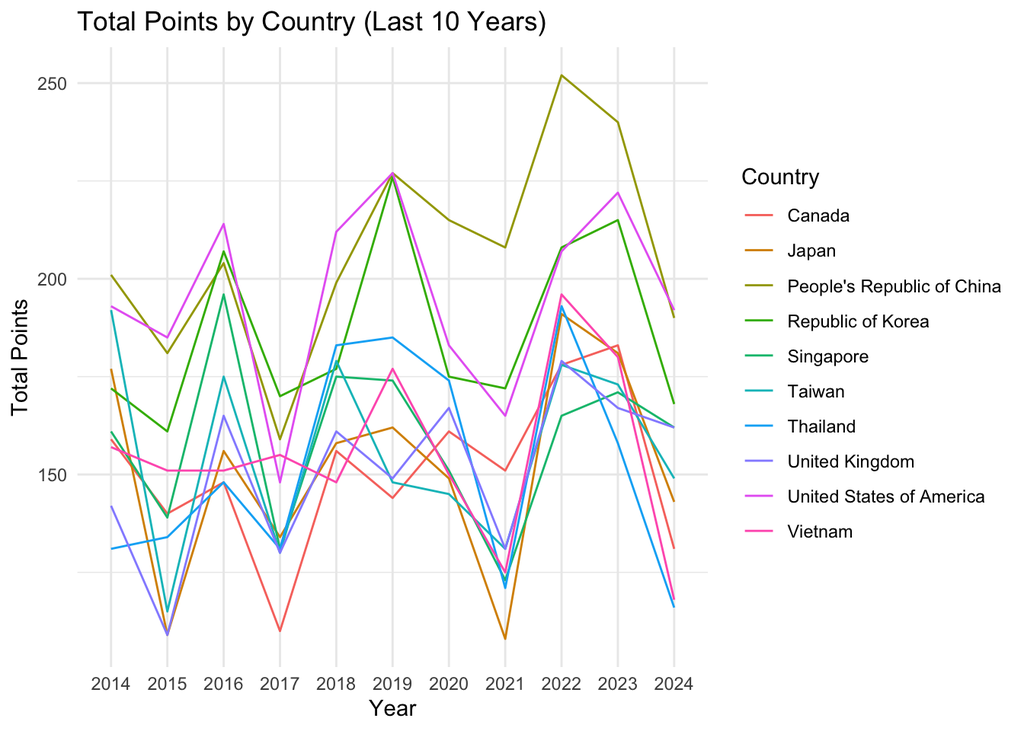

```r
# Create the plot
ggplot(tidy_data_filtered_top_10, aes(x = year, y = total_points, color = country, group = country)) +
  geom_line() +
  labs(title = "Total Points by Country (Last 10 Years)",
       x = "Year",
       y = "Total Points",
       color = "Country") +
  theme_minimal()
```

## Dataset 2 —:

Description

```r
world_data <- read.csv(dataLink2)
head(world_data)
```

|  | Rank | CCA3 | Country.Territory | Capital | Continent | X2022.Population | X2020.Population | X2015.Population | X2010.Population | X2000.Population | X1990.Population | X1980.Population | X1970.Population | Area..km.. | Density..per.km.. | Growth.Rate | World.Population.Percentage |
| --- | --- | --- | --- | --- | --- | --- | --- | --- | --- | --- | --- | --- | --- | --- | --- | --- | --- |
| 1 | 36 | AFG | Afghanistan | Kabul | Asia | 41128771 | 38972230 | 33753499 | 28189672 | 19542982 | 10694796 | 12486631 | 10752971 | 652230 | 63.0587 | 1.0257 | 0.52 |
| 2 | 138 | ALB | Albania | Tirana | Europe | 2842321 | 2866849 | 2882481 | 2913399 | 3182021 | 3295066 | 2941651 | 2324731 | 28748 | 98.8702 | 0.9957 | 0.04 |
| 3 | 34 | DZA | Algeria | Algiers | Africa | 44903225 | 43451666 | 39543154 | 35856344 | 30774621 | 25518074 | 18739378 | 13795915 | 2381741 | 18.8531 | 1.0164 | 0.56 |
| 4 | 213 | ASM | American Samoa | Pago Pago | Oceania | 44273 | 46189 | 51368 | 54849 | 58230 | 47818 | 32886 | 27075 | 199 | 222.4774 | 0.9831 | 0.00 |
| 5 | 203 | AND | Andorra | Andorra la Vella | Europe | 79824 | 77700 | 71746 | 71519 | 66097 | 53569 | 35611 | 19860 | 468 | 170.5641 | 1.0100 | 0.00 |
| 6 | 42 | AGO | Angola | Luanda | Africa | 35588987 | 33428485 | 28127721 | 23364185 | 16394062 | 11828638 | 8330047 | 6029700 | 1246700 | 28.5466 | 1.0315 | 0.45 |

## Dataset 2 Tidy Data:

```r
world_data <- world_data %>%
  rename("Country/Territory" = Country.Territory, "2022" = X2022.Population, "2020" = X2020.Population, "2015" = X2015.Population, "2010" = X2010.Population, "2000" = X2000.Population, "1990" = X1990.Population, "1980" = X1980.Population, "1970" = X1970.Population, "Area (km)" = Area..km.., "Density per km" = Density..per.km.., "Growth Rate" = Growth.Rate, "World Population Percentage" = World.Population.Percentage)

world_data_long <- world_data %>%
  pivot_longer(`2022`:`1970`, names_to = "Year", values_to = "Population")

head(world_data_long)
```

| Rank | CCA3 | Country/Territory | Capital | Continent | Area (km) | Density per km | Growth Rate | World Population Percentage | Year | Population |
| --- | --- | --- | --- | --- | --- | --- | --- | --- | --- | --- |
| 36 | AFG | Afghanistan | Kabul | Asia | 652230 | 63.0587 | 1.0257 | 0.52 | 2022 | 41128771 |
| 36 | AFG | Afghanistan | Kabul | Asia | 652230 | 63.0587 | 1.0257 | 0.52 | 2020 | 38972230 |
| 36 | AFG | Afghanistan | Kabul | Asia | 652230 | 63.0587 | 1.0257 | 0.52 | 2015 | 33753499 |
| 36 | AFG | Afghanistan | Kabul | Asia | 652230 | 63.0587 | 1.0257 | 0.52 | 2010 | 28189672 |
| 36 | AFG | Afghanistan | Kabul | Asia | 652230 | 63.0587 | 1.0257 | 0.52 | 2000 | 19542982 |
| 36 | AFG | Afghanistan | Kabul | Asia | 652230 | 63.0587 | 1.0257 | 0.52 | 1990 | 10694796 |

```r
world_data_tidy <- world_data_long %>%
  group_by(Year, Continent) %>%
  summarise(Total_Population = sum(Population))
world_data_tidy$Year <- as.numeric(as.character(world_data_tidy$Year))

glimpse(world_data_tidy)
```

```
## Rows: 48
## Columns: 3
## Groups: Year [8]
## $ Year             <dbl> 1970, 1970, 1970, 1970, 1970, 1970, 1980, 1980, 1980,…
## $ Continent        <chr> "Africa", "Asia", "Europe", "North America", "Oceania…
## $ Total_Population <dbl> 365444348, 2144906290, 655923991, 315434606, 19480270…
```

## Dataset 2 Data Analysis:

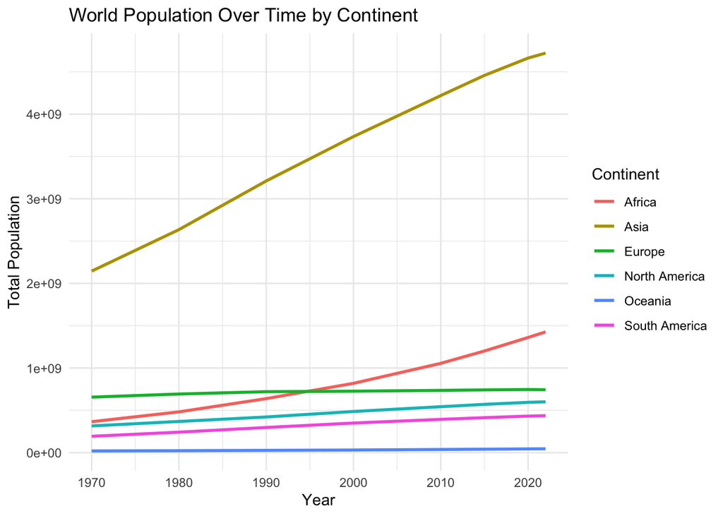

```r
ggplot(data = world_data_tidy, aes(x = Year, y = Total_Population, color = Continent)) +
  geom_line(linewidth = 1) +
  ggtitle("World Population Over Time by Continent") +
  xlab("Year") +
  ylab("Total Population") +
  theme_minimal()
```

## Dataset 2 Conclusion: In conclusion the data was tidied to showcase only the total population for each continent over the years. The data was then graphed on a line graph. It showcases the countries with the high total population (Asia) and the lowest (Oceania). It also showcases the trends and slope throguhtout the years. ## Dataset 3 —: Description

```r
mta_data <- read_csv(dataLink3)
head(mta_data)
```

| Date | Subways: Total Estimated Ridership | Subways: % of Comparable Pre-Pandemic Day | Buses: Total Estimated Ridership | Buses: % of Comparable Pre-Pandemic Day | LIRR: Total Estimated Ridership | LIRR: % of Comparable Pre-Pandemic Day | Metro-North: Total Estimated Ridership | Metro-North: % of Comparable Pre-Pandemic Day | Access-A-Ride: Total Scheduled Trips | Access-A-Ride: % of Comparable Pre-Pandemic Day | Bridges and Tunnels: Total Traffic | Bridges and Tunnels: % of Comparable Pre-Pandemic Day | Staten Island Railway: Total Estimated Ridership | Staten Island Railway: % of Comparable Pre-Pandemic Day |
| --- | --- | --- | --- | --- | --- | --- | --- | --- | --- | --- | --- | --- | --- | --- |
| 3/1/20 | 2212965 | 97 | 984908 | 99 | 86790 | 100 | 55825 | 59 | 19922 | 113 | 786960 | 98 | 1636 | 52 |
| 3/2/20 | 5329915 | 96 | 2209066 | 99 | 321569 | 103 | 180701 | 66 | 30338 | 102 | 874619 | 95 | 17140 | 107 |
| 3/3/20 | 5481103 | 98 | 2228608 | 99 | 319727 | 102 | 190648 | 69 | 32767 | 110 | 882175 | 96 | 17453 | 109 |
| 3/4/20 | 5498809 | 99 | 2177165 | 97 | 311662 | 99 | 192689 | 70 | 34297 | 115 | 905558 | 98 | 17136 | 107 |
| 3/5/20 | 5496453 | 99 | 2244515 | 100 | 307597 | 98 | 194386 | 70 | 33209 | 112 | 929298 | 101 | 17203 | 108 |
| 3/6/20 | 5189447 | 93 | 2066743 | 92 | 289171 | 92 | 205056 | 74 | 30970 | 104 | 945408 | 103 | 15285 | 96 |

## Dataset 3 Tidy Data:

```r
# Change from wide to long data
mta_data_long <- mta_data %>%
  pivot_longer(-Date, names_to =c("transportation","percent_prepandemic"),
               names_sep = ":", ) %>%
  pivot_wider(names_from = percent_prepandemic, values_from = value)

mta_data_long <- mta_data_long %>%
  select(-c(` Total Scheduled Trips`, ` Total Traffic`))

mta_data_long <- mta_data_long %>%
  rename(total_ridership = ` Total Estimated Ridership`)

head(mta_data_long)
```

| Date | transportation | total_ridership | % of Comparable Pre-Pandemic Day |
| --- | --- | --- | --- |
| 3/1/20 | Subways | 2212965 | 97 |
| 3/1/20 | Buses | 984908 | 99 |
| 3/1/20 | LIRR | 86790 | 100 |
| 3/1/20 | Metro-North | 55825 | 59 |
| 3/1/20 | Access-A-Ride | NA | 113 |
| 3/1/20 | Bridges and Tunnels | NA | 98 |

```r
glimpse(mta_data_long)
```

```
## Rows: 11,697
## Columns: 4
## $ Date                                <chr> "3/1/20", "3/1/20", "3/1/20", "3/1…
## $ transportation                      <chr> "Subways", "Buses", "LIRR", "Metro…
## $ total_ridership                     <dbl> 2212965, 984908, 86790, 55825, NA,…
## $ ` % of Comparable Pre-Pandemic Day` <dbl> 97, 99, 100, 59, 113, 98, 52, 96, …
```

```r
# Convert the date column to a proper date format
mta_data_long$Date <- as.Date(mta_data_long$Date, format = "%m/%d/%y")

# Extract the year from the date column
mta_data_long$Year <- as.numeric(format(mta_data_long$Date, "%Y"))

# View the first few rows of the updated DataFrame
head(mta_data_long)
```

| Date | transportation | total_ridership | % of Comparable Pre-Pandemic Day | Year |
| --- | --- | --- | --- | --- |
| 2020-03-01 | Subways | 2212965 | 97 | 2020 |
| 2020-03-01 | Buses | 984908 | 99 | 2020 |
| 2020-03-01 | LIRR | 86790 | 100 | 2020 |
| 2020-03-01 | Metro-North | 55825 | 59 | 2020 |
| 2020-03-01 | Access-A-Ride | NA | 113 | 2020 |
| 2020-03-01 | Bridges and Tunnels | NA | 98 | 2020 |

```r
mta_data_tidy <- mta_data_long %>%
  group_by(Year, transportation) %>%
  summarize(mean_total_ride = mean(total_ridership))
glimpse(mta_data_tidy)
```

```
## Rows: 35
## Columns: 3
## Groups: Year [5]
## $ Year            <dbl> 2020, 2020, 2020, 2020, 2020, 2020, 2020, 2021, 2021, …
## $ transportation  <chr> "Access-A-Ride", "Bridges and Tunnels", "Buses", "LIRR…
## $ mean_total_ride <dbl> NA, NA, 481659.147, 58224.588, 37544.441, 2359.206, 12…
```

## Dataset 3 Data Analysis:

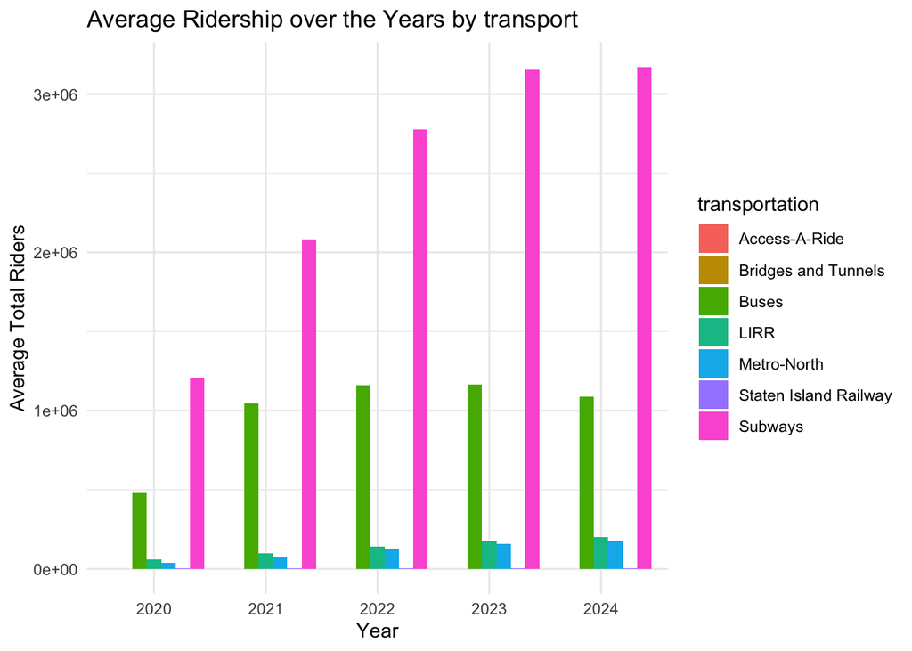

```r
ggplot(data = mta_data_tidy, aes(x = factor(Year), y = mean_total_ride, fill = transportation)) +
  geom_bar(stat = "identity", position = "dodge") +
  ggtitle("Average Ridership over the Years by transport") +
  xlab("Year") +
  ylab("Average Total Riders") +
  theme_minimal() +
  scale_x_discrete(labels = c("2020", "2021", "2022", "2023", "2024"))
```